# ReadQuakes

## Visualisation of EuroMed Earthquakes from the INGV EuroSeismos project

## http://storing.rm.ingv.it/es_web/ using python

Part I: This is a first summary of the earthquake data contained within the INGV database in order to first understand what is included in this database. After that we may perform some spatial analysis to further understand this dataset The earthquake data in this notebook have been downloaded from here: http://storing.rm.ingv.it/es_web/

##### Some of things we are showing here are the following:

- Review content of INGV Euro - Mediterranean earthquakes dataset
- Show how to read the csv file & show different ways to summarize the dataset
- How to print few lines from a file in order to check contents
- Sort and summarize data and plot it

# Data Summary & Content

The datasets we are reading have been downloaded from the INGV website provided above, and provide a list of what kind of events we have per country and per year The reason behind this is to understand the content as-of-date of the INGV database as a repository of historical earthquakes for the European

## Mediterranean region

```python
# importing the required modules
import matplotlib.pyplot as plt
import numpy as np
import geopandas as gpd
from matplotlib_scalebar.scalebar import ScaleBar
```

```python
# Close all graphics windows that are open
plt.close('all')
```

```python
# Reading a CSV File
# There are various ways to read a CSV file that uses either the CSV module or the pandas library.
# https://www.geeksforgeeks.org/reading-csv-files-in-python/?ref=lbp

import csv
import pandas as pd
import os # If we need to change our working directory we need to import os
```

```python
os.getcwd() # first lets check what our working directory is
```

```
'C:\\Users\\abarbe05\\Box\\My Box Notes\\HistoricalEarthquakes'
```

## Eartthquakes in the European Mediterranean between 1895 and 1930

```python
# opening the CSV file
with open('EuroMed_quakes_1895To1930.csv', mode='r') as file:
    # reading the CSV file
    csvFile = csv.reader(file)

#    # displaying the contents of the CSV file
#    for lines in csvFile:
#        print(lines[5:1])
```

```python
# reading the 1895 to 1930 CSV file using pandas library
qk1895_1930_df = pd.read_csv("EuroMed_quakes_1895To1930.csv")
qk1895_1930_df
```

|  | NTERR | ns | R | Year | Mo | Da | Ho | Mi | Se | Lat | Lon | Io | M | Prior | Req | Epicentral_Zone | Country |
| --- | --- | --- | --- | --- | --- | --- | --- | --- | --- | --- | --- | --- | --- | --- | --- | --- | --- |
| 0 | 60001 | NaN | NaN | 1896 | 3 | 11 | 23 | 0 | NaN | 45.70 | 26.60 | 7 | 6.6 | B | Oros | Vrancea / Romania | Romania |
| 1 | 60002 | 3.0 | NaN | 1896 | 6 | 29 | 20 | 46 | 43 | 30.30 | 33.00 | NaN | 6.5 | A | Solomi | NaN | Egypt |
| 2 | 60003 | 8.0 | NaN | 1896 | 9 | 22 | 5 | 0 | 0 | 41.60 | 45.20 | 7.5 | 5.6 | B | Elashvili | NaN | Georgia |
| 3 | 60004 | NaN | NaN | 1896 | 11 | 24 | 18 | 50 | NaN | 45.70 | 26.60 | 6.5 | 6.1 | C | Oros | Vrancea / Romania | Romania |
| 4 | 60005 | NaN | NaN | 1899 | 2 | 14 | 16 | 58 | NaN | 48.12 | 7.65 | 7 | 4.1 | A | Kaiser | Kaiserstuhl | Germany |
| ... | ... | ... | ... | ... | ... | ... | ... | ... | ... | ... | ... | ... | ... | ... | ... | ... | ... |
| 297 | 60273 | 17.0 | NaN | 1930 | 7 | 4 | 21 | 6 | NaN | 45.19 | 6.35 | 5.5 | NaN | C | Scotti | Massif De La Vanoise | France |
| 298 | 60274 | 36.0 | NaN | 1930 | 7 | 5 | 23 | 11 | 41 | 37.61 | -4.62 | 8 | 5.2 | A | Batll&oacute; | Near Cordoba, S Spain | Spain |
| 299 | 30013 | 96.0 | NaN | 1930 | 7 | 23 | 0 | 8 | 0 | 41.05 | 15.37 | 10 | 6.7 | A | Pino - Ferrari | Irpinia | Italy |
| 300 | 30094 | 73.0 | NaN | 1930 | 10 | 30 | 7 | 13 | 6 | 43.67 | 13.27 | 8 | 5.9 | A | Pino - Ferrari | Marche Settentrionali | Italy |
| 301 | 60275 | 55.0 | NaN | 1930 | 11 | 21 | 2 | 0 | 27 | 40.20 | 19.60 | 9 | 6.1 | A | Duni | Southern Albania | Albania |

302 rows × 17 columns

```python
qk1895_1930_df.head()
```

|  | NTERR | ns | R | Year | Mo | Da | Ho | Mi | Se | Lat | Lon | Io | M | Prior | Req | Epicentral_Zone | Country |
| --- | --- | --- | --- | --- | --- | --- | --- | --- | --- | --- | --- | --- | --- | --- | --- | --- | --- |
| 0 | 60001 | NaN | NaN | 1896 | 3 | 11 | 23 | 0 | NaN | 45.70 | 26.60 | 7 | 6.6 | B | Oros | Vrancea / Romania | Romania |
| 1 | 60002 | 3.0 | NaN | 1896 | 6 | 29 | 20 | 46 | 43 | 30.30 | 33.00 | NaN | 6.5 | A | Solomi | NaN | Egypt |
| 2 | 60003 | 8.0 | NaN | 1896 | 9 | 22 | 5 | 0 | 0 | 41.60 | 45.20 | 7.5 | 5.6 | B | Elashvili | NaN | Georgia |
| 3 | 60004 | NaN | NaN | 1896 | 11 | 24 | 18 | 50 | NaN | 45.70 | 26.60 | 6.5 | 6.1 | C | Oros | Vrancea / Romania | Romania |
| 4 | 60005 | NaN | NaN | 1899 | 2 | 14 | 16 | 58 | NaN | 48.12 | 7.65 | 7 | 4.1 | A | Kaiser | Kaiserstuhl | Germany |

```python
qk1895_1930_df.Country # print content of column Country in this file
```

```
0      Romania
1        Egypt
2      Georgia
3      Romania
4      Germany
        ...
297     France
298      Spain
299      Italy
300      Italy
301    Albania
Name: Country, Length: 302, dtype: object
```

```python
qk1895_1930_df[qk1895_1930_df.Country == 'Greece'] # print contents which relate to Country Greece
```

|  | NTERR | ns | R | Year | Mo | Da | Ho | Mi | Se | Lat | Lon | Io | M | Prior | Req | Epicentral_Zone | Country |
| --- | --- | --- | --- | --- | --- | --- | --- | --- | --- | --- | --- | --- | --- | --- | --- | --- | --- |
| 29 | 60031 | 4.0 | NaN | 1902 | 7 | 5 | 14 | 32 | NaN | 40.75 | 23.25 | 9 | 6.5 | B | Batll&oacute; | N Greece | Greece |
| 30 | 60030 | 4.0 | NaN | 1902 | 7 | 5 | 14 | 56 | 0 | 40.80 | 23.00 | 9 | 6.6 | A | Pekevski | NaN | Greece |
| 135 | 60129 | 36.0 | NaN | 1912 | 1 | 24 | 16 | 22 | 51 | 38.10 | 20.80 | 10 | 6.8 | A | Baskoutas | Asprogerakas | Greece |
| 176 | 60164 | 23.0 | NaN | 1916 | 9 | 27 | 15 | 2 | 13 | 38.90 | 23.00 | 8 | 5.9 | B | Baskoutas | Lichada | Greece |
| 180 | 60167 | 39.0 | NaN | 1917 | 5 | 23 | 5 | 46 | 27 | 39.00 | 20.40 | 6 | 6.1 | A | Baskoutas | Preveza | Greece |
| 182 | 60169 | 20.0 | NaN | 1917 | 12 | 24 | 9 | 13 | 55 | 38.40 | 21.80 | 8 | 6.0 | B | Baskoutas | Naupaktos | Greece |
| 197 | 60183 | 38.0 | NaN | 1919 | 12 | 22 | 23 | 40 | 0 | 40.10 | 20.70 | 8.5 | 6.1 | B | Pekevski | NaN | Greece |
| 198 | 60182 | 38.0 | NaN | 1919 | 12 | 22 | 23 | 41 | 6 | 40.10 | 20.70 | 9 | 6.3 | A | Baskoutas | Leskovik | Greece |
| 217 | 60201 | 32.0 | NaN | 1923 | 8 | 1 | 8 | 16 | 38 | 35.00 | 25.00 | 4 | 6.8 | A | Baskoutas | Anoghia | Greece |
| 222 | 60206 | 43.0 | * | 1923 | 12 | 5 | 20 | 56 | 35 | 39.80 | 23.50 | 8 | 6.4 | A | Baskoutas - Pekevski | Kasandria | Greece |
| 237 | 60221 | 52.0 | NaN | 1925 | 7 | 6 | 12 | 15 | 55 | 37.80 | 22.10 | 6 | 6.6 | A | Baskoutas | Kato Klitori | Greece |
| 253 | 60236 | 53.0 | NaN | 1926 | 8 | 30 | 11 | 38 | 12 | 36.80 | 23.30 | 8 | 7.2 | A | Baskoutas | Sparti | Greece |
| 265 | 60248 | 44.0 | NaN | 1927 | 7 | 1 | 8 | 18 | 54 | 36.70 | 22.70 | 9 | 7.1 | A | Baskoutas | Oetylo | Greece |

```python
quakes1895To1930_yr=qk1895_1930_df.groupby('Year').aggregate({'NTERR':'count'}) # group earthquakes in dataset by year and aggregate so we can see how many earthquakes we have per year
```

```python
quakes1895To1930_yr
```

| Year | NTERR |
| --- | --- |
| 1896 | 4 |
| 1899 | 4 |
| 1900 | 6 |
| 1901 | 9 |
| 1902 | 9 |
| 1903 | 11 |
| 1904 | 9 |
| 1905 | 15 |
| 1906 | 6 |
| 1907 | 9 |
| 1908 | 11 |
| 1909 | 13 |
| 1910 | 14 |
| 1911 | 14 |
| 1912 | 14 |
| 1913 | 7 |
| 1914 | 4 |
| 1915 | 9 |
| 1916 | 9 |
| 1917 | 6 |
| 1918 | 5 |
| 1919 | 11 |
| 1920 | 6 |
| 1921 | 5 |
| 1922 | 4 |
| 1923 | 9 |
| 1924 | 12 |
| 1925 | 8 |
| 1926 | 15 |
| 1927 | 14 |
| 1928 | 10 |
| 1929 | 12 |
| 1930 | 8 |

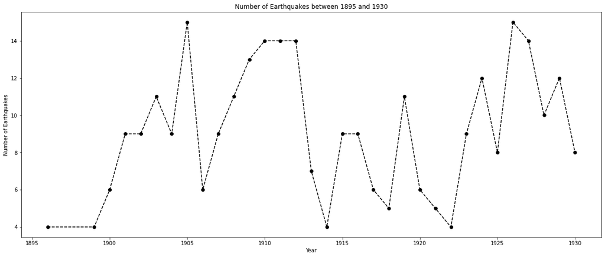

```python
plt.figure(figsize = (20, 8))
plt.plot(quakes1895To1930_yr.NTERR, color='black',linestyle='--',marker='o')
plt.xlabel("Year")
plt.ylabel("Number of Earthquakes")
plt.title("Number of Earthquakes between 1895 and 1930")
plt.show()
```

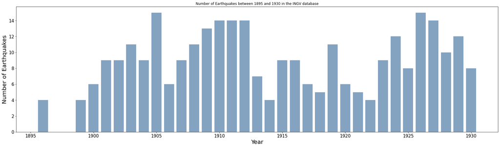

```python
plt.figure(figsize = (30, 8))
qyr = qk1895_1930_df.groupby( ["Year"] ).size().reset_index(name='count')
xy = qyr['Year'] # what goes on the x-axis
yy = qyr['count']   # what goes on the y-axis
plt.bar(xy,yy, color=(0.2, 0.4, 0.6, 0.6))
# plt.plot(avocados_boston.date, avocados_boston.average_price, color = 'green', linestyle = '--', marker = 'o')
plt.xlabel("Year",fontsize=20)
plt.ylabel("Number of Earthquakes",fontsize=20)
plt.title("Number of Earthquakes between 1895 and 1930 in the INGV database")
plt.xticks(fontsize=15)
plt.yticks(fontsize=15)
plt.show()
```

```python
#  applying group_by function to
# group the data on group value.
# Dataframe is quakes
by_country_quakes = qk1895_1930_df.groupby('Country')
print(by_country_quakes['Country'].count())
```

```
Country
Albania                 11
Algeria                  5
Armenia                  1
Atlantic_Ocean           9
Azerbaijan               5
Belgium                  2
Bosnia_Herzegovina       3
Bulgaria                16
Croatia                 19
Cyprus                   2
Czech_Republic           2
Egypt                    4
Finland                  2
France                  28
Georgia                  5
Germany                 30
Greece                  13
Italy                   24
Jordan                   2
Lebanon                  3
Mediterranean_sea       24
Norway                   3
Portugal                11
Red_Sea                  1
Romania                 42
Russian_Federation       6
Slovenia                 1
Spain                   13
Sweden                   1
Switzerland              7
Syrian_Arab_Republic     2
Turkey                   2
Yugoslavia               3
Name: Country, dtype: int64
```

```python
data = by_country_quakes['Country'].count() # lets save these grouped data
```

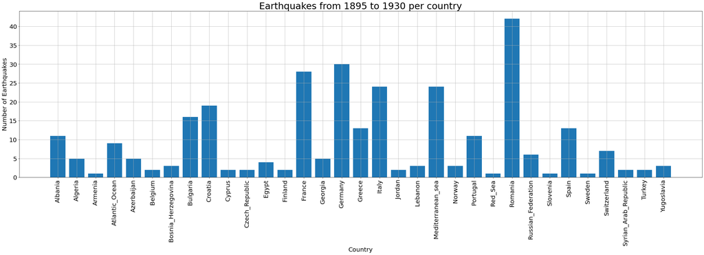

```python
# How do we plot now the aggregate data to make a bar graph?
# This resolves the issue
plt.rcParams["figure.figsize"] = (40,10)

d1 = qk1895_1930_df.groupby( ["Country"] ).size().reset_index(name='count')
x = d1['Country'] # what goes on the x-axis
y = d1['count']   # what goes on the y-axis

# naming the x axis
plt.xlabel('Country', fontsize=20)
# naming the y axis
plt.ylabel('Number of Earthquakes', fontsize=20)
plt.bar(x,y)
plt.xticks(rotation = 'vertical') # rotates x-axis labels for better viewing and fit
plt.title('Earthquakes from 1895 to 1930 per country', fontsize=30)

plt.xticks(fontsize=20)
plt.yticks(fontsize=20)

plt.grid(True)
plt.show()
```

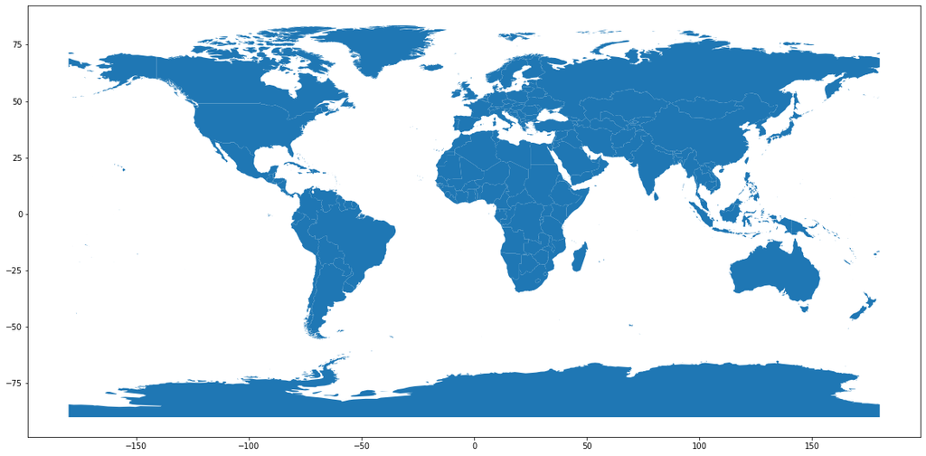

```python
import fiona
world_map = gpd.read_file('world_countries.shp')  # read shapefile and create dataframe associated with respect to file
geo_df = gpd.GeoDataFrame(world_map, crs = 'epsg:4326')
world_map.plot() # plot the world map
plt.show() # Make graphics visible
```

```python
# Create geodataframe for the locations of earthquakes
plot_locs_gdf = gpd.GeoDataFrame(qk1895_1930_df, geometry=gpd.points_from_xy(qk1895_1930_df.Lon, qk1895_1930_df.Lat), crs='epsg:4326')
```

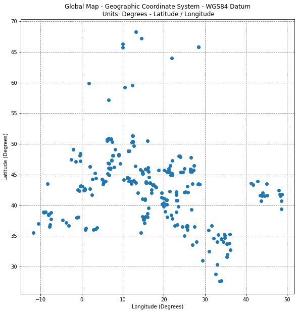

```python
fig, ax = plt.subplots()
plot_locs_gdf.plot(ax=ax)
# plt.title("Map of Plot Locations", color='k')
ax.set(xlabel="Longitude (Degrees)", ylabel="Latitude (Degrees)", title="Global Map - Geographic Coordinate System - WGS84 Datum\n Units: Degrees - Latitude / Longitude")
ax.set_axisbelow(True)
ax.yaxis.grid(color='gray', linestyle='dashed')
ax.xaxis.grid(color='gray', linestyle='dashed')
plt.show()
```

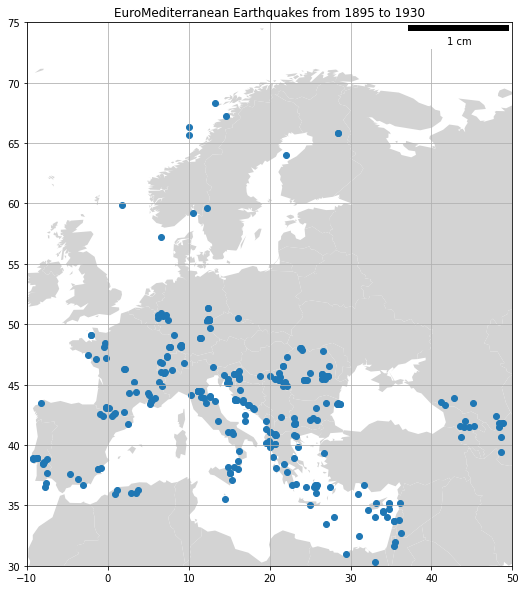

```python
fig, ax = plt.subplots(figsize = (10,10))
world_map.to_crs(epsg=4326).plot(ax=ax, color='lightgrey')
plot_locs_gdf.plot(ax=ax)
ax.set_title('EuroMediterranean Earthquakes from 1895 to 1930')
ax.set_ylim([30,75]) # set x-axis limits
ax.set_xlim([-10,50]) # set y-axis limits
# Create scale bar
scalebar = ScaleBar(0.08, "cm", length_fraction=0.25)
ax.add_artist(scalebar)
plt.grid(True)
plt.show()
```

# Now lets look at the earthquakes from 1931 to 1962

```python
# reading the CSV file using pandas library
qk1931_1962_df = pd.read_csv("EuroMed_quakes_1931To1962.csv")
qk1931_1962_df
```

|  | NTERR | ns | R | Year | Mo | Da | Ho | Mi | Se | Lat | Lon | Io | M | Prior | Req | Epicentral_Zone | Country | Notes |
| --- | --- | --- | --- | --- | --- | --- | --- | --- | --- | --- | --- | --- | --- | --- | --- | --- | --- | --- |
| 0 | 60276 | 61 | * | 1931 | 3 | 7 | 0 | 16 | 44.8 | 41.28 | 22.50 | 8 | 6.0 | A | Pekevski - Batll&oacute; | Macedonia | Macedonia | NaN |
| 1 | 60277 | 82 | * | 1931 | 3 | 8 | 1 | 50 | 24.0 | 41.28 | 22.50 | 10 | 6.7 | A | Baskoutas - Pekevski | Valandovo | Macedonia | NaN |
| 2 | 60278 | 6 | NaN | 1931 | 4 | 7 | 1 | 42 | NaN | 48.22 | 22.69 | 6 | 3.9 | C | Oros | North - Western Romania | Hungary | NaN |
| 3 | 60279 | 5 | NaN | 1931 | 4 | 12 | 21 | 25 | NaN | 49.90 | 17.90 | 6 | NaN | B | Zednik | NaN | Czech_Republic | NaN |
| 4 | 60280 | 68 | NaN | 1931 | 4 | 27 | 16 | 50 | 45.0 | 39.20 | 46.00 | 8.5 | 6.3 | A | Elashvili | NaN | Azerbaijan | NaN |
| ... | ... | ... | ... | ... | ... | ... | ... | ... | ... | ... | ... | ... | ... | ... | ... | ... | ... | ... |
| 231 | 60493 | 78 | NaN | 1962 | 4 | 25 | 4 | 44 | NaN | 45.00 | 5.57 | 7.5 | 5.3 | A | Cara | Corren&ccedil;on (Alpes) | France | 5,3 / 4,8 |
| 232 | 34638 | 187 | NaN | 1962 | 8 | 21 | 18 | 9 | 2.0 | 41.13 | 15.12 | 8.5 | 5.8 | A | Pino - Ferrari | Irpinia | Italy | NaN |
| 233 | 34641 | 187 | NaN | 1962 | 8 | 21 | 18 | 19 | 30.0 | 41.23 | 14.95 | 9 | 6.2 | A | Pino - Ferrari | Irpinia | Italy | NaN |
| 234 | 60494 | 41 | NaN | 1962 | 9 | 5 | 19 | 35 | NaN | 50.40 | 12.40 | 5.5 | NaN | A | Zednik | NaN | Germany | NaN |
| 235 | 60495 | 62 | NaN | 1962 | 10 | 4 | 19 | 29 | NaN | 50.40 | 12.40 | 5.5 | NaN | A | Zednik | NaN | Germany | NaN |

236 rows × 18 columns

```python
qk1931_1962_df.head()
```

|  | NTERR | ns | R | Year | Mo | Da | Ho | Mi | Se | Lat | Lon | Io | M | Prior | Req | Epicentral_Zone | Country | Notes |
| --- | --- | --- | --- | --- | --- | --- | --- | --- | --- | --- | --- | --- | --- | --- | --- | --- | --- | --- |
| 0 | 60276 | 61 | * | 1931 | 3 | 7 | 0 | 16 | 44.8 | 41.28 | 22.50 | 8 | 6.0 | A | Pekevski - Batll&oacute; | Macedonia | Macedonia | NaN |
| 1 | 60277 | 82 | * | 1931 | 3 | 8 | 1 | 50 | 24.0 | 41.28 | 22.50 | 10 | 6.7 | A | Baskoutas - Pekevski | Valandovo | Macedonia | NaN |
| 2 | 60278 | 6 | NaN | 1931 | 4 | 7 | 1 | 42 | NaN | 48.22 | 22.69 | 6 | 3.9 | C | Oros | North - Western Romania | Hungary | NaN |
| 3 | 60279 | 5 | NaN | 1931 | 4 | 12 | 21 | 25 | NaN | 49.90 | 17.90 | 6 | NaN | B | Zednik | NaN | Czech_Republic | NaN |
| 4 | 60280 | 68 | NaN | 1931 | 4 | 27 | 16 | 50 | 45.0 | 39.20 | 46.00 | 8.5 | 6.3 | A | Elashvili | NaN | Azerbaijan | NaN |

```python
quakes1931To1962_yr=qk1931_1962_df.groupby('Year').aggregate({'NTERR':'count'}) # group earthquakes in dataset by year and aggregate so we can see how many earthquakes we have per year
```

```python
quakes1931To1962_yr
```

| Year | NTERR |
| --- | --- |
| 1931 | 8 |
| 1932 | 5 |
| 1933 | 6 |
| 1934 | 8 |
| 1935 | 14 |
| 1936 | 9 |
| 1937 | 4 |
| 1938 | 10 |
| 1939 | 3 |
| 1940 | 11 |
| 1941 | 6 |
| 1942 | 5 |
| 1943 | 14 |
| 1945 | 5 |
| 1946 | 11 |
| 1947 | 6 |
| 1948 | 7 |
| 1949 | 4 |
| 1950 | 7 |
| 1951 | 9 |
| 1952 | 10 |
| 1953 | 7 |
| 1954 | 9 |
| 1955 | 6 |
| 1956 | 9 |
| 1957 | 7 |
| 1958 | 9 |
| 1959 | 10 |
| 1960 | 6 |
| 1961 | 2 |
| 1962 | 9 |

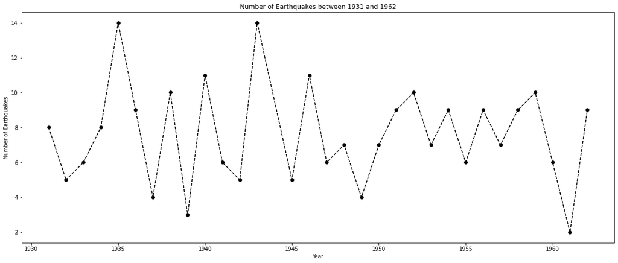

```python
plt.figure(figsize = (20, 8))
plt.plot(quakes1931To1962_yr.NTERR, color='black',linestyle='--',marker='o')
plt.xlabel("Year")
plt.ylabel("Number of Earthquakes")
plt.title("Number of Earthquakes between 1931 and 1962")
plt.show()
```

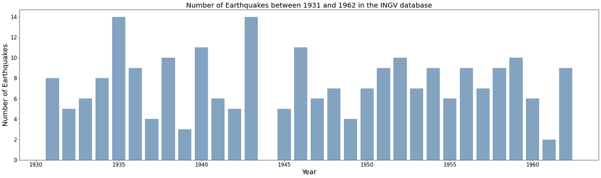

```python
plt.figure(figsize = (30, 8))
qyr2 = qk1931_1962_df.groupby( ["Year"] ).size().reset_index(name='count')
xy = qyr2['Year'] # what goes on the x-axis
yy = qyr2['count']   # what goes on the y-axis
plt.bar(xy,yy, color=(0.2, 0.4, 0.6, 0.6))
# plt.plot(avocados_boston.date, avocados_boston.average_price, color = 'green', linestyle = '--', marker = 'o')
plt.xlabel("Year",fontsize=20)
plt.ylabel("Number of Earthquakes",fontsize=20)
plt.title("Number of Earthquakes between 1931 and 1962 in the INGV database",fontsize=20)
plt.xticks(fontsize=15)
plt.yticks(fontsize=15)
plt.show()
```

```python
#  applying group_by function to
# group the data on group value.
# Dataframe is quakes
by_country_quakes = qk1931_1962_df.groupby('Country')
print(by_country_quakes['Country'].count())
```

```
Country
Albania                4
Algeria                5
Atlantic_Ocean         8
Austria                2
Azerbaijan             2
Belgium                3
Bosnia_Herzegovina     1
Bulgaria               1
Croatia                8
Cyprus                 6
Czech_Republic         3
Egypt                  4
Finland                1
France                51
Georgia                2
Germany               28
Greece                 8
Hungary                2
Italy                 11
Jordan                 2
Lebanon                3
Macedonia              2
Mediterranean_sea     20
Netherlands            2
Norway                 1
Portugal               2
Red_Sea                1
Romania               28
Russian_Federation     1
Slovenia               2
Spain                  9
Switzerland            8
Turkey                 2
Ukraine                1
United_Kingdom         1
Yugoslavia             1
Name: Country, dtype: int64
```

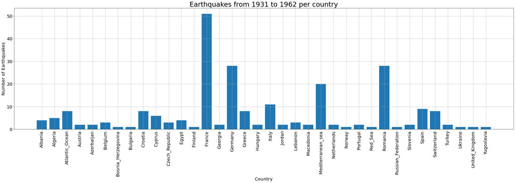

```python
# How do we plot now the aggregate data to make a bar graph?
# This resolves the issue
plt.rcParams["figure.figsize"] = (40,10)

qyr2 = qk1931_1962_df.groupby( ["Country"] ).size().reset_index(name='count')
x = qyr2['Country'] # what goes on the x-axis
y = qyr2['count']   # what goes on the y-axis

# naming the x axis
plt.xlabel('Country', fontsize=20)
# naming the y axis
plt.ylabel('Number of Earthquakes', fontsize=20)
plt.bar(x,y)
plt.xticks(rotation = 'vertical') # rotates x-axis labels for better viewing and fit
plt.title('Earthquakes from 1931 to 1962 per country', fontsize=30)

plt.xticks(fontsize=20)
plt.yticks(fontsize=20)

plt.grid(True)
plt.show()
```

```python
# Create geodataframe for the locations of earthquakes
plot_locs2_gdf = gpd.GeoDataFrame(qk1931_1962_df, geometry=gpd.points_from_xy(qk1931_1962_df.Lon, qk1931_1962_df.Lat), crs='epsg:4326')
```

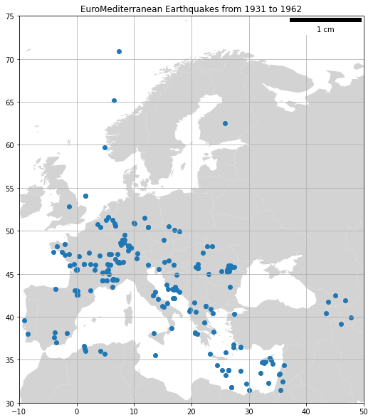

```python
fig, ax = plt.subplots(figsize = (10,10))
world_map.to_crs(epsg=4326).plot(ax=ax, color='lightgrey')
plot_locs2_gdf.plot(ax=ax)
ax.set_title('EuroMediterranean Earthquakes from 1931 to 1962')
ax.set_ylim([30,75]) # set x-axis limits
ax.set_xlim([-10,50]) # set y-axis limits
# Create scale bar
scalebar = ScaleBar(0.08, "cm", length_fraction=0.25)
ax.add_artist(scalebar)
plt.grid(True)
plt.show()
```

# More recent earthquakes between 1963 and 1990 in the INGV database

```python
# reading the CSV file using pandas library
qk1963_1990_df = pd.read_csv("EuroMed_quakes_1963To1990.csv")
qk1963_1990_df
```

|  | NTERR | ns | R | Year | Mo | Da | Ho | Mi | Se | Lat | Lon | Io | M | Prior | Req | Epicentral_Zone | Country | Notes |
| --- | --- | --- | --- | --- | --- | --- | --- | --- | --- | --- | --- | --- | --- | --- | --- | --- | --- | --- |
| 0 | 60496 | 46 | NaN | 1963 | 1 | 14 | 18 | 33 | 24 | 45.90 | 26.70 | 6 | 5.8 | C | Oros | Vrancea / Romania | Romania | NaN |
| 1 | 60497 | 42 | NaN | 1963 | 2 | 14 | 13 | 18 | 54 | 44.26 | 15.17 | 6 | 4.8 | B | Allegretti | Zadar (N - Dalmatia) | Croatia | NaN |
| 2 | 60498 | 41 | NaN | 1963 | 2 | 22 | 14 | 12 | 51 | 40.20 | 20.00 | 7 | 5.2 | B | Duni | Southern Albania | Albania | NaN |
| 3 | 60499 | 60 | NaN | 1963 | 4 | 25 | 13 | 36 | NaN | 44.93 | 5.67 | 7 | 4.8 | A | Cara | Monteynard (Alpes) | France | 4,8 / 4,5 |
| 4 | 60500 | 47 | NaN | 1963 | 4 | 27 | 5 | 28 | NaN | 44.93 | 5.65 | 7 | 4.4 | A | Cara | Monteynard (Alpes) | France | 4,4 / 4,3 |
| ... | ... | ... | ... | ... | ... | ... | ... | ... | ... | ... | ... | ... | ... | ... | ... | ... | ... | ... |
| 121 | 60597 | 13 | NaN | 1990 | 4 | 12 | 7 | 3 | 59.9 | 35.66 | 11.89 | NaN | 5.2 | C | Hofstetter | NaN | Mediterranean_sea | NaN |
| 122 | 60598 | 14 | NaN | 1990 | 5 | 3 | 21 | 4 | 29.1 | 43.28 | 37.10 | NaN | 5.2 | C | Hofstetter | NaN | Mediterranean_sea | NaN |
| 123 | 60599 | 17 | NaN | 1990 | 7 | 18 | 11 | 29 | 34.7 | 36.76 | 29.11 | NaN | 5.1 | C | Hofstetter | NaN | Turkey | NaN |
| 124 | 60600 | 13 | NaN | 1990 | 10 | 29 | 8 | 16 | 28.1 | 36.12 | 16.48 | NaN | 5.1 | C | Hofstetter | NaN | Mediterranean_sea | NaN |
| 125 | 60601 | 30 | NaN | 1990 | 12 | 21 | 6 | 57 | 43.3 | 40.93 | 22.41 | 8 | 5.5 | B | Pekevski | NaN | Greece | NaN |

126 rows × 18 columns

```python
quakes1963To1990_yr=qk1963_1990_df.groupby('Year').aggregate({'NTERR':'count'}) # group earthquakes in dataset by year and aggregate so we can see how many earthquakes we have per year
```

```python
quakes1963To1990_yr
```

| Year | NTERR |
| --- | --- |
| 1963 | 9 |
| 1964 | 4 |
| 1965 | 4 |
| 1966 | 2 |
| 1967 | 3 |
| 1968 | 6 |
| 1969 | 15 |
| 1970 | 8 |
| 1971 | 3 |
| 1972 | 3 |
| 1973 | 1 |
| 1974 | 3 |
| 1975 | 2 |
| 1976 | 11 |
| 1977 | 1 |
| 1978 | 5 |
| 1979 | 8 |
| 1980 | 3 |
| 1981 | 1 |
| 1982 | 1 |
| 1983 | 2 |
| 1984 | 6 |
| 1985 | 4 |
| 1986 | 3 |
| 1987 | 3 |
| 1988 | 4 |
| 1989 | 5 |
| 1990 | 6 |

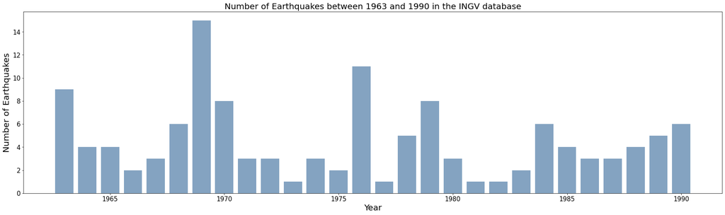

```python
plt.figure(figsize = (30, 8))
qyr3 = qk1963_1990_df.groupby( ["Year"] ).size().reset_index(name='count')
xy = qyr3['Year'] # what goes on the x-axis
yy = qyr3['count']   # what goes on the y-axis
plt.bar(xy,yy, color=(0.2, 0.4, 0.6, 0.6))
# plt.plot(avocados_boston.date, avocados_boston.average_price, color = 'green', linestyle = '--', marker = 'o')
plt.xlabel("Year",fontsize=20)
plt.ylabel("Number of Earthquakes",fontsize=20)
plt.title("Number of Earthquakes between 1963 and 1990 in the INGV database",fontsize=20)
plt.xticks(fontsize=15)
plt.yticks(fontsize=15)
plt.show()
```

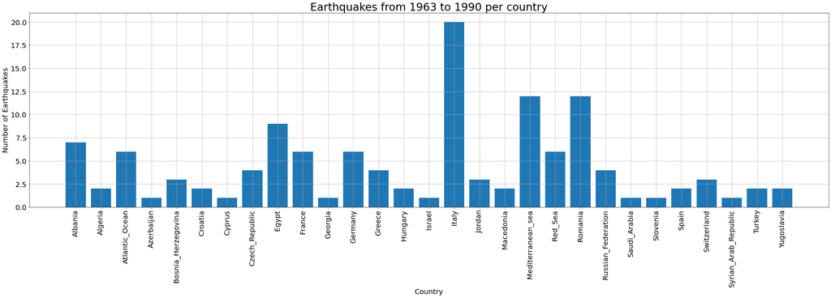

```python
# How do we plot now the aggregate data to make a bar graph?
# This resolves the issue
plt.rcParams["figure.figsize"] = (40,10)

qyr3 = qk1963_1990_df.groupby( ["Country"] ).size().reset_index(name='count')
x = qyr3['Country'] # what goes on the x-axis
y = qyr3['count']   # what goes on the y-axis

# naming the x axis
plt.xlabel('Country', fontsize=20)
# naming the y axis
plt.ylabel('Number of Earthquakes', fontsize=20)
plt.bar(x,y)
plt.xticks(rotation = 'vertical') # rotates x-axis labels for better viewing and fit
plt.title('Earthquakes from 1963 to 1990 per country', fontsize=30)

plt.xticks(fontsize=20)
plt.yticks(fontsize=20)

plt.grid(True)
plt.show()
```

```python
# Create geodataframe for the locations of earthquakes
plot_locs3_gdf = gpd.GeoDataFrame(qk1963_1990_df, geometry=gpd.points_from_xy(qk1963_1990_df.Lon, qk1963_1990_df.Lat), crs='epsg:4326')
```

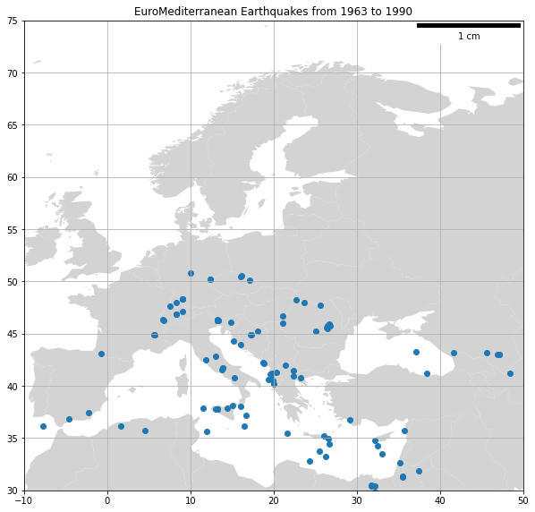

```python
fig, ax = plt.subplots(figsize = (10,10))
world_map.to_crs(epsg=4326).plot(ax=ax, color='lightgrey')
plot_locs3_gdf.plot(ax=ax)
ax.set_title('EuroMediterranean Earthquakes from 1963 to 1990')
ax.set_ylim([30,75]) # set x-axis limits
ax.set_xlim([-10,50]) # set y-axis limits
# Create scale bar
scalebar = ScaleBar(0.08, "cm", length_fraction=0.25)
ax.add_artist(scalebar)
plt.grid(True)
plt.show()
```

```python
302+236+126
```

```
664
```

# Earthquakes in the Euro Mediterranean region prior to 1895

```python
# reading the CSV file using pandas library
qkbefore_1895_df = pd.read_csv("EuroMed_quakes_Before1895.csv")
qkbefore_1895_df
```

|  | NTERR | ns | R | Year | Mo | Da | Ho | Mi | Se | Lat | Lon | Io | M | Prior | Req | Epicentral_Zone | Country |
| --- | --- | --- | --- | --- | --- | --- | --- | --- | --- | --- | --- | --- | --- | --- | --- | --- | --- |
| 0 | 61046 | NaN | b | 1879 | 5 | 18 | 23 | 0 | -- | 48.00 | 23.30 | 6.5 | 4.6 | B | Oros | North - Western Romania | Romania |
| 1 | 61047 | NaN | b | 1879 | 9 | 28 | 15 | 30 | -- | 44.80 | 21.50 | 7.0 | 4.7 | A | Oros | Romania/Yugoslavia Border | Romania |
| 2 | 61050 | NaN | b | 1879 | 10 | 10 | 15 | 45 | -- | 44.70 | 21.60 | 8.0 | 5.3 | A | Oros | Romania/Yugoslavia Border | Romania |
| 3 | 61048 | NaN | b | 1879 | 10 | 10 | 18 | 30 | -- | 44.70 | 21.60 | 7.0 | 4.7 | A | Oros | Romania/Yugoslavia Border | Romania |
| 4 | 61049 | NaN | b | 1879 | 10 | 10 | 19 | 30 | -- | 44.70 | 21.60 | 7.0 | 4.7 | A | Oros | Romania/Yugoslavia Border | Romania |
| 5 | 61051 | NaN | b | 1879 | 10 | 11 | 1 | 0 | -- | 44.70 | 21.60 | 7.0 | 4.7 | A | Oros | Romania/Yugoslavia Border | Romania |
| 6 | 61053 | NaN | b | 1879 | 10 | 11 | 2 | 45 | -- | 44.70 | 21.60 | 8.0 | 5.3 | A | Oros | Romania/Yugoslavia Border | Romania |
| 7 | 61052 | NaN | b | 1879 | 10 | 11 | 10 | 45 | -- | 44.70 | 21.60 | 7.0 | 4.7 | A | Oros | Romania/Yugoslavia Border | Romania |
| 8 | 61054 | NaN | b | 1879 | 10 | 17 | 2 | 53 | -- | 44.70 | 21.60 | 7.0 | 4.7 | A | Oros | Romania/Yugoslavia Border | Romania |
| 9 | 61055 | NaN | b | 1879 | 10 | 20 | 10 | 45 | -- | 44.70 | 21.70 | 7.0 | 4.7 | A | Oros | Romania/Yugoslavia Border | Romania |
| 10 | 61056 | NaN | b | 1879 | 10 | 31 | 18 | 30 | -- | 46.10 | 20.60 | 7.0 | 4.7 | A | Oros | Western Romania | Romania |
| 11 | 61057 | NaN | b | 1879 | 10 | 31 | 18 | 31 | -- | 45.90 | 20.40 | 7.0 | 4.7 | A | Oros | Western Romania | Yugoslavia |
| 12 | 61058 | NaN | b | 1879 | 11 | 1 | 6 | 0 | -- | 46.00 | 20.50 | 7.0 | 4.7 | A | Oros | Western Romania | Romania |
| 13 | 61059 | NaN | b | 1879 | 11 | 19 | 23 | 10 | -- | 45.80 | 21.30 | 7.0 | 4.7 | A | Oros | Western Romania | Romania |
| 14 | 61060 | NaN | b | 1879 | 12 | 22 | 4 | 3 | -- | 44.70 | 21.60 | 7.0 | 4.7 | A | Oros | Romania/Yugoslavia Border | Romania |
| 15 | 61061 | NaN | b | 1880 | 1 | 17 | 14 | 15 | -- | 48.10 | 23.80 | 6.0 | 4.1 | B | Oros | North - Western Romania | Ukraine |
| 16 | 61062 | NaN | b | 1880 | 2 | 23 | 21 | 30 | -- | 44.50 | 21.60 | 7.0 | 4.7 | A | Oros | Romania/Yugoslavia Border | Yugoslavia |
| 17 | 61063 | NaN | b | 1880 | 3 | 1 | 2 | 45 | -- | 44.70 | 21.60 | 7.0 | 4.7 | A | Oros | Romania/Yugoslavia Border | Romania |
| 18 | 61064 | NaN | b | 1880 | 4 | 13 | 12 | 20 | -- | 44.60 | 21.60 | 7.0 | 4.7 | A | Oros | Romania/Yugoslavia Border | Yugoslavia |
| 19 | 61065 | NaN | b | 1880 | 10 | 3 | 5 | 46 | -- | 46.30 | 24.10 | 8.0 | 5.3 | A | Oros | Centre Of Romania | Romania |
| 20 | 61066 | NaN | b | 1880 | 12 | 25 | 14 | 30 | -- | 45.70 | 26.60 | 7.5 | 6.8 | A | Oros | Vrancea / Romania | Romania |
| 21 | 61067 | NaN | b | 1884 | 12 | 25 | 21 | 8 | 9 | 36.95 | -3.98 | 10.0 | 6.7 | A | Batll&oacute; | Granada, Se Spain | Spain |
| 22 | 61068 | NaN | b | 1885 | 5 | 26 | 8 | 29 | -- | 47.30 | 23.20 | 6.0 | 4.1 | B | Oros | North - Western Romania | Romania |
| 23 | 61069 | NaN | b | 1886 | 4 | 12 | 21 | 20 | -- | 47.00 | 21.90 | 6.0 | 4.1 | B | Oros | North - Western Romania | Romania |
| 24 | 61070 | NaN | b | 1887 | 7 | 10 | 2 | 56 | -- | 46.00 | 21.20 | 7.0 | 4.7 | A | Oros | Western Romania | Romania |
| 25 | 61071 | NaN | b | 1888 | 8 | 19 | 4 | 56 | -- | 43.50 | 26.60 | 7.0 | 6.5 | B | Oros | Romania/Bulgaria Border | Bulgaria |
| 26 | 61072 | NaN | b | 1891 | 50 | 50 | 50 | 0 | 0 | 43.00 | 41.20 | 8.0 | 6.0 | A | Elashvili | NaN | Georgia |
| 27 | 61073 | NaN | b | 1892 | 10 | 14 | 6 | 50 | -- | 43.50 | 27.60 | 8.0 | 6.5 | A | Oros | Romania/Bulgaria Border | Bulgaria |
| 28 | 61074 | NaN | b | 1893 | 3 | 11 | 9 | 25 | -- | 48.00 | 23.00 | 7.0 | 4.7 | A | Oros | North - Western Romania | Romania |
| 29 | 61075 | NaN | b | 1893 | 5 | 1 | 17 | 18 | -- | 45.70 | 26.60 | 6.5 | 6.2 | B | Oros | Vrancea / Romania | Romania |
| 30 | 61076 | NaN | b | 1893 | 8 | 17 | 14 | 45 | -- | 45.70 | 26.60 | 8.0 | 7.1 | A | Oros | Vrancea / Romania | Romania |
| 31 | 61077 | NaN | b | 1893 | 9 | 10 | 3 | 40 | -- | 45.70 | 26.60 | 7.0 | 6.5 | B | Oros | Vrancea / Romania | Romania |
| 32 | 61078 | NaN | b | 1894 | 3 | 4 | 6 | 35 | -- | 45.70 | 26.60 | 7.0 | 6.5 | B | Oros | Vrancea / Romania | Romania |
| 33 | 61079 | NaN | b | 1894 | 8 | 31 | 12 | 20 | -- | 45.70 | 26.60 | 8.0 | 7.1 | A | Oros | Vrancea / Romania | Romania |
| 34 | 61080 | NaN | b | 1894 | 10 | 7 | 2 | 0 | -- | 48.10 | 23.50 | 6.5 | 4.8 | B | Oros | North - Western Romania | Ukraine |
| 35 | 61081 | NaN | b | 1894 | 12 | 19 | 21 | 30 | -- | 45.00 | 21.70 | 7.0 | 4.7 | A | Oros | Western Romania | Romania |

```python
quakes_before1895_yr=qkbefore_1895_df.groupby('Year').aggregate({'NTERR':'count'}) # group earthquakes in dataset by year and aggregate so we can see how many earthquakes we have per year
```

```python
quakes_before1895_yr
```

| Year | NTERR |
| --- | --- |
| 1879 | 15 |
| 1880 | 6 |
| 1884 | 1 |
| 1885 | 1 |
| 1886 | 1 |
| 1887 | 1 |
| 1888 | 1 |
| 1891 | 1 |
| 1892 | 1 |
| 1893 | 4 |
| 1894 | 4 |

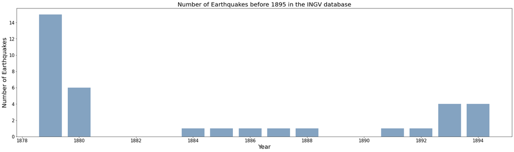

```python
plt.figure(figsize = (30, 8))
qyr4 = qkbefore_1895_df.groupby( ["Year"] ).size().reset_index(name='count')
xy = qyr4['Year'] # what goes on the x-axis
yy = qyr4['count']   # what goes on the y-axis
plt.bar(xy,yy, color=(0.2, 0.4, 0.6, 0.6))
# plt.plot(avocados_boston.date, avocados_boston.average_price, color = 'green', linestyle = '--', marker = 'o')
plt.xlabel("Year",fontsize=20)
plt.ylabel("Number of Earthquakes",fontsize=20)
plt.title("Number of Earthquakes before 1895 in the INGV database",fontsize=20)
plt.xticks(fontsize=15)
plt.yticks(fontsize=15)
plt.show()
```

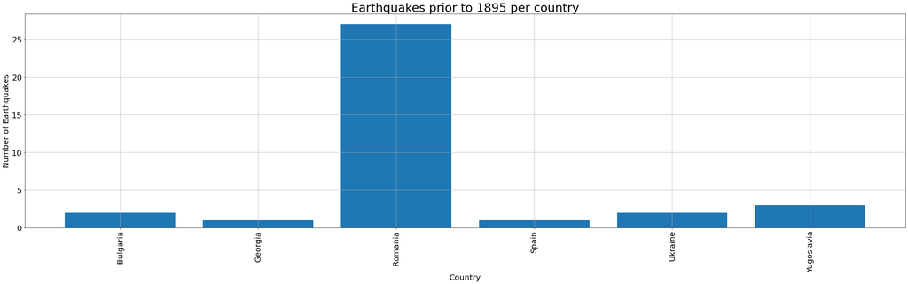

```python
# How do we plot now the aggregate data to make a bar graph?
# This resolves the issue
plt.rcParams["figure.figsize"] = (40,10)

qyr4 = qkbefore_1895_df.groupby( ["Country"] ).size().reset_index(name='count')
x = qyr4['Country'] # what goes on the x-axis
y = qyr4['count']   # what goes on the y-axis

# naming the x axis
plt.xlabel('Country', fontsize=20)
# naming the y axis
plt.ylabel('Number of Earthquakes', fontsize=20)
plt.bar(x,y)
plt.xticks(rotation = 'vertical') # rotates x-axis labels for better viewing and fit
plt.title('Earthquakes prior to 1895 per country', fontsize=30)

plt.xticks(fontsize=20)
plt.yticks(fontsize=20)

plt.grid(True)
plt.show()
```

```python
Total1=d1['count'].sum()
Total2=qyr2['count'].sum()
Total3=qyr3['count'].sum()
Total4=qyr4['count'].sum()
```

```python
print('The total number of earthquakes contained in the dataset 1963-1990 is:', Total3)
```

```
The total number of earthquakes contained in the dataset 1963-1990 is: 126
```

```python
print('The total number of earthquakes contained in the dataset 1931-1962 is:', Total2)
```

```
The total number of earthquakes contained in the dataset 1931-1962 is: 236
```

```python
print('The total number of earthquakes contained in the dataset 1895-1930 is:', Total1)
```

```
The total number of earthquakes contained in the dataset 1895-1930 is: 302
```

```python
print('The total number of earthquakes contained in the dataset Prior to 1895 is:', Total4)
```

```
The total number of earthquakes contained in the dataset Prior to 1895 is: 36
```

```python
print('The total number of earthquakes at this point contained by INGV are:',Total1+Total2+Total3+Total4)
```

```
The total number of earthquakes at this point contained by INGV are: 700
```

```python
302+236+126+36
```

```
700
```

```python
# Create geodataframe for the locations of earthquakes
plot_locs4_gdf = gpd.GeoDataFrame(qkbefore_1895_df, geometry=gpd.points_from_xy(qkbefore_1895_df.Lon, qkbefore_1895_df.Lat), crs='epsg:4326')
```

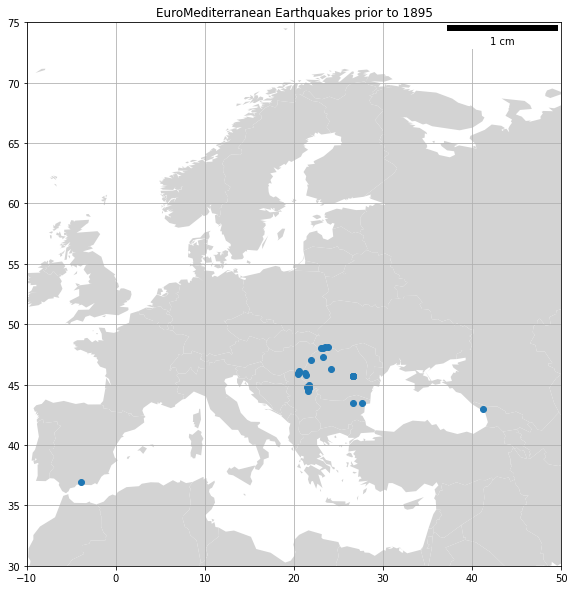

```python
fig, ax = plt.subplots(figsize = (10,10))
world_map.to_crs(epsg=4326).plot(ax=ax, color='lightgrey')
plot_locs4_gdf.plot(ax=ax)
ax.set_title('EuroMediterranean Earthquakes prior to 1895')
ax.set_ylim([30,75]) # set x-axis limits
ax.set_xlim([-10,50]) # set y-axis limits
# Create scale bar
scalebar = ScaleBar(0.08, "cm", length_fraction=0.25)
ax.add_artist(scalebar)
plt.grid(True)
plt.show()
```

```python
qyr4
```

|  | Country | count |
| --- | --- | --- |
| 0 | Bulgaria | 2 |
| 1 | Georgia | 1 |
| 2 | Romania | 27 |
| 3 | Spain | 1 |
| 4 | Ukraine | 2 |
| 5 | Yugoslavia | 3 |

```python
# reading the post 1990 CSV file using pandas library
qkAfter1990_df = pd.read_csv("EuroMed_quakes_After1990.csv")
len(qkAfter1990_df)
```

```
46
```

## Since we are interested in earthquakes in Greece it does not make sense to work with the last dataset from INGV

We are though concatenating all data so we can also summarize the whole dataset

```python
from glob import glob
```

```python
glob('EuroMed_quakes*.csv')
```

```
['EuroMed_quakes_1895To1930.csv',
 'EuroMed_quakes_1931To1962.csv',
 'EuroMed_quakes_1963To1990.csv',
 'EuroMed_quakes_After1990.csv',
 'EuroMed_quakes_Before1895.csv']
```

```python
glob_quakes=glob('EuroMed_quakes*.csv')
```

```python
newlist=[]
for filename in glob_quakes:
  if "a" in filename:
    newlist.append(pd.read_csv(filename))
```

```python
# for filename in filenames:
#    dfs.append(pd.read_csv(filename))

# Concatenate all data into one DataFrame
ingv = pd.concat(newlist, ignore_index=True)
len(ingv)
```

```
746
```

```python
ingv.head()
```

|  | NTERR | ns | R | Year | Mo | Da | Ho | Mi | Se | Lat | Lon | Io | M | Prior | Req | Epicentral_Zone | Country | Notes |
| --- | --- | --- | --- | --- | --- | --- | --- | --- | --- | --- | --- | --- | --- | --- | --- | --- | --- | --- |
| 0 | 60001 | NaN | NaN | 1896 | 3 | 11 | 23 | 0 | NaN | 45.70 | 26.60 | 7 | 6.6 | B | Oros | Vrancea / Romania | Romania | NaN |
| 1 | 60002 | 3.0 | NaN | 1896 | 6 | 29 | 20 | 46 | 43 | 30.30 | 33.00 | NaN | 6.5 | A | Solomi | NaN | Egypt | NaN |
| 2 | 60003 | 8.0 | NaN | 1896 | 9 | 22 | 5 | 0 | 0 | 41.60 | 45.20 | 7.5 | 5.6 | B | Elashvili | NaN | Georgia | NaN |
| 3 | 60004 | NaN | NaN | 1896 | 11 | 24 | 18 | 50 | NaN | 45.70 | 26.60 | 6.5 | 6.1 | C | Oros | Vrancea / Romania | Romania | NaN |
| 4 | 60005 | NaN | NaN | 1899 | 2 | 14 | 16 | 58 | NaN | 48.12 | 7.65 | 7 | 4.1 | A | Kaiser | Kaiserstuhl | Germany | NaN |

```python
len(ingv)
```

```
746
```

```python
ingv_df=ingv.groupby('Year').aggregate({'NTERR':'count'}) # group earthquakes in dataset by year and aggregate so we can see how many earthquakes we have per year
```

```python
ingv_df
```

| Year | NTERR |
| --- | --- |
| 1879 | 15 |
| 1880 | 6 |
| 1884 | 1 |
| 1885 | 1 |
| 1886 | 1 |
| ... | ... |
| 1995 | 1 |
| 1996 | 2 |
| 1997 | 1 |
| 1998 | 1 |
| 1999 | 2 |

112 rows × 1 columns

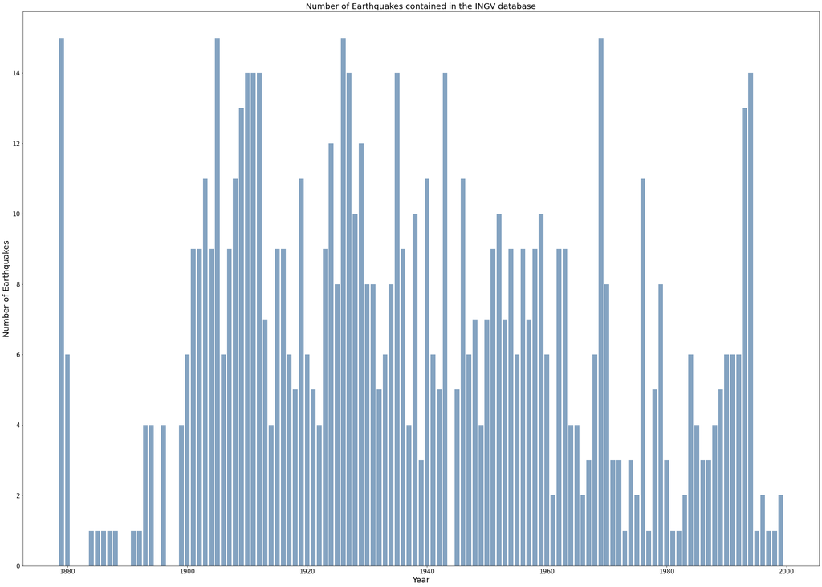

```python
plt.figure(figsize = (35, 25))
yearly = ingv.groupby( ["Year"] ).size().reset_index(name='count')
xy = yearly['Year'] # what goes on the x-axis
yy = yearly['count']   # what goes on the y-axis
plt.bar(xy,yy, color=(0.2, 0.4, 0.6, 0.6))
plt.xlabel("Year",fontsize=20)
plt.ylabel("Number of Earthquakes",fontsize=20)
plt.title("Number of Earthquakes contained in the INGV database",fontsize=20)
plt.xticks(fontsize=15)
plt.yticks(fontsize=15)
plt.show()
```

```python
ingv_country=ingv.groupby('Country').aggregate({'NTERR':'count'}) # group earthquakes in dataset by year and aggregate so we can see how many earthquakes we have per year
```

```python
ingv_country
```

| Country | NTERR |
| --- | --- |
| Albania | 22 |
| Algeria | 12 |
| Armenia | 1 |
| Atlantic_Ocean | 23 |
| Austria | 2 |
| Azerbaijan | 9 |
| Belgium | 5 |
| Bosnia_Herzegovina | 7 |
| Bulgaria | 19 |
| Croatia | 29 |
| Cyprus | 9 |
| Czech_Republic | 9 |
| Egypt | 26 |
| Ethiopia | 1 |
| Finland | 3 |
| France | 87 |
| Georgia | 9 |
| Germany | 64 |
| Greece | 32 |
| Hungary | 4 |
| Iran | 1 |
| Israel | 1 |
| Italy | 55 |
| Jordan | 7 |
| Lebanon | 6 |
| Macedonia | 5 |
| Mediterranean_sea | 63 |
| Netherlands | 2 |
| Norway | 4 |
| Portugal | 13 |
| Red_Sea | 12 |
| Romania | 109 |
| Russian_Federation | 11 |
| Saudi_Arabia | 2 |
| Slovenia | 4 |
| Spain | 25 |
| Sudan | 1 |
| Sweden | 1 |
| Switzerland | 19 |
| Syrian_Arab_Republic | 3 |
| Turkey | 16 |
| Ukraine | 3 |
| United_Kingdom | 1 |
| Yugoslavia | 9 |

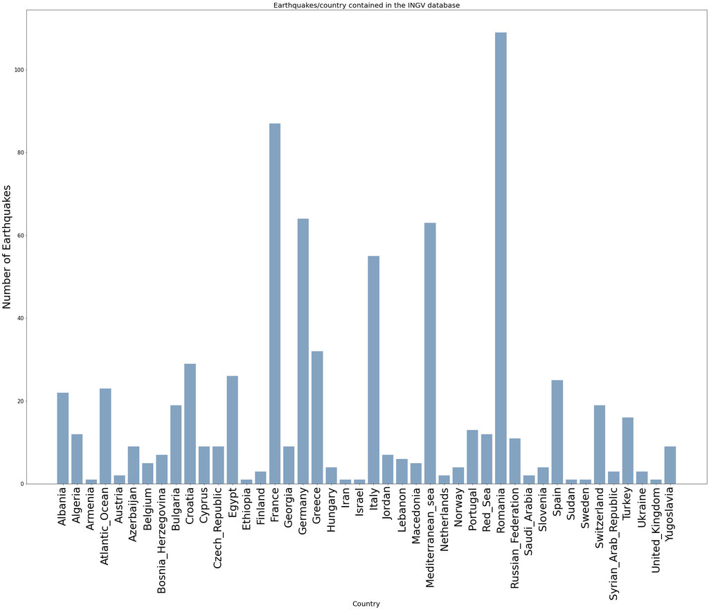

```python
plt.figure(figsize = (35, 25))
yearly = ingv.groupby( ["Country"] ).size().reset_index(name='count')
xy = yearly['Country'] # what goes on the x-axis
yy = yearly['count']   # what goes on the y-axis
plt.bar(xy,yy, color=(0.2, 0.4, 0.6, 0.6))
plt.xlabel("Country",fontsize=20)
plt.ylabel("Number of Earthquakes",fontsize=30)
plt.title("Earthquakes/country contained in the INGV database",fontsize=20)
plt.xticks(rotation = 'vertical',fontsize=30) # rotates x-axis labels for better viewing and fit
# plt.xticks(fontsize=15)
plt.yticks(fontsize=15)
plt.show()
```

```python
# Create geodataframe for the locations of earthquakes
quakes_gdf = gpd.GeoDataFrame(ingv, geometry=gpd.points_from_xy(ingv.Lon, ingv.Lat), crs='epsg:4326')
```

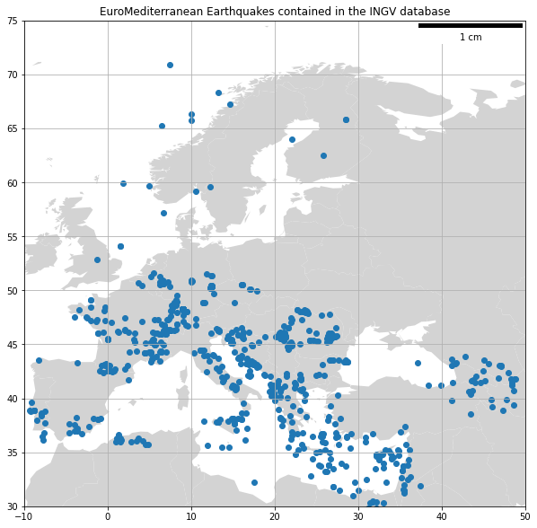

```python
fig, ax = plt.subplots(figsize = (10,10))
world_map.to_crs(epsg=4326).plot(ax=ax, color='lightgrey')
quakes_gdf.plot(ax=ax)
ax.set_title('EuroMediterranean Earthquakes contained in the INGV database')
ax.set_ylim([30,75]) # set x-axis limits
ax.set_xlim([-10,50]) # set y-axis limits
# Create scale bar
scalebar = ScaleBar(0.08, "cm", length_fraction=0.25)
ax.add_artist(scalebar)
plt.grid(True)
plt.show()
```

```python
quakes_gdf.head()
```

|  | NTERR | ns | R | Year | Mo | Da | Ho | Mi | Se | Lat | Lon | Io | M | Prior | Req | Epicentral_Zone | Country | Notes | geometry |
| --- | --- | --- | --- | --- | --- | --- | --- | --- | --- | --- | --- | --- | --- | --- | --- | --- | --- | --- | --- |
| 0 | 60001 | NaN | NaN | 1896 | 3 | 11 | 23 | 0 | NaN | 45.70 | 26.60 | 7 | 6.6 | B | Oros | Vrancea / Romania | Romania | NaN | POINT (26.60000 45.70000) |
| 1 | 60002 | 3.0 | NaN | 1896 | 6 | 29 | 20 | 46 | 43 | 30.30 | 33.00 | NaN | 6.5 | A | Solomi | NaN | Egypt | NaN | POINT (33.00000 30.30000) |
| 2 | 60003 | 8.0 | NaN | 1896 | 9 | 22 | 5 | 0 | 0 | 41.60 | 45.20 | 7.5 | 5.6 | B | Elashvili | NaN | Georgia | NaN | POINT (45.20000 41.60000) |
| 3 | 60004 | NaN | NaN | 1896 | 11 | 24 | 18 | 50 | NaN | 45.70 | 26.60 | 6.5 | 6.1 | C | Oros | Vrancea / Romania | Romania | NaN | POINT (26.60000 45.70000) |
| 4 | 60005 | NaN | NaN | 1899 | 2 | 14 | 16 | 58 | NaN | 48.12 | 7.65 | 7 | 4.1 | A | Kaiser | Kaiserstuhl | Germany | NaN | POINT (7.65000 48.12000) |

```python
import numpy as np
```

```python
gdf_points=quakes_gdf.copy()
gdf_points_utm=gdf_points.to_crs('EPSG:7791')
gdf_points_utm.head(6)
```

|  | NTERR | ns | R | Year | Mo | Da | Ho | Mi | Se | Lat | Lon | Io | M | Prior | Req | Epicentral_Zone | Country | Notes | geometry |
| --- | --- | --- | --- | --- | --- | --- | --- | --- | --- | --- | --- | --- | --- | --- | --- | --- | --- | --- | --- |
| 0 | 60001 | NaN | NaN | 1896 | 3 | 11 | 23 | 0 | NaN | 45.70 | 26.60 | 7 | 6.6 | B | Oros | Vrancea / Romania | Romania | NaN | POINT (1869343.259 5213625.927) |
| 1 | 60002 | 3.0 | NaN | 1896 | 6 | 29 | 20 | 46 | 43 | 30.30 | 33.00 | NaN | 6.5 | A | Solomi | NaN | Egypt | NaN | POINT (2840690.940 3608884.655) |
| 2 | 60003 | 8.0 | NaN | 1896 | 9 | 22 | 5 | 0 | 0 | 41.60 | 45.20 | 7.5 | 5.6 | B | Elashvili | NaN | Georgia | NaN | POINT (3528550.507 5289131.087) |
| 3 | 60004 | NaN | NaN | 1896 | 11 | 24 | 18 | 50 | NaN | 45.70 | 26.60 | 6.5 | 6.1 | C | Oros | Vrancea / Romania | Romania | NaN | POINT (1869343.259 5213625.927) |
| 4 | 60005 | NaN | NaN | 1899 | 2 | 14 | 16 | 58 | NaN | 48.12 | 7.65 | 7 | 4.1 | A | Kaiser | Kaiserstuhl | Germany | NaN | POINT (399530.831 5330519.205) |
| 5 | 60006 | 9.0 | NaN | 1899 | 5 | 15 | 10 | 57 | 0 | 43.60 | 16.70 | 8 | 0.0 | B | Allegretti | Trilj (M - Dalmatia) | Croatia | NaN | POINT (1121562.877 4856339.614) |

```python
gdf_points_utm['geometry'] = gdf_points_utm['geometry'].centroid
```

```python
s=ingv.M
s.astype(float)
```

```
0      6.6
1      6.5
2      5.6
3      6.1
4      4.1
      ...
741    6.5
742    6.5
743    7.1
744    4.8
745    4.7
Name: M, Length: 746, dtype: float64
```

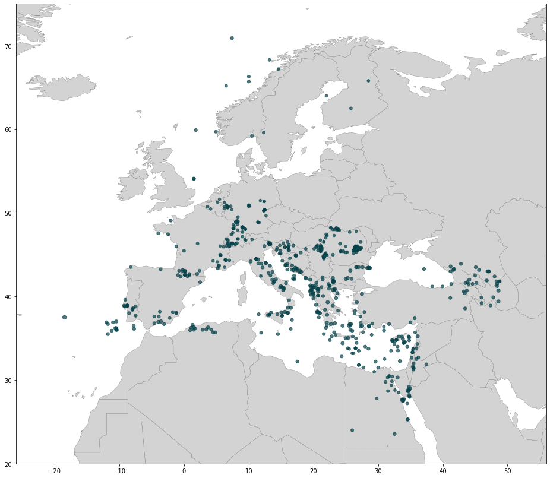

```python
fig, ax = plt.subplots(figsize=(16,16))
ax.set_ylim([20,75]) # set x-axis limits
ax.set_xlim([-26,56]) # set y-axis limits
world_map.plot(ax=ax, color="lightgray", edgecolor="grey", linewidth=0.4)
quakes_gdf.plot(ax=ax,color="#07424A",markersize=s*5,alpha=0.7, categorical=False, legend=True)
# ax.axis("off")
# plt.axis("equal")
plt.show()
```

```python
Greek_quakes=ingv[ingv.Country == 'Greece'] # print contents which relate to Country Greece
```

```python
Greek_quakes.agg({'NTERR':'count'})
```

```
NTERR    32
dtype: int64
```

```python
max(Greek_quakes.M)
```

```
7.2
```

```python
#  applying group_by function to
# group the data on group value.
# Dataframe is quakes
by_country = ingv.groupby('Country')
print(by_country['Country'].count())
```

```
Country
Albania                  22
Algeria                  12
Armenia                   1
Atlantic_Ocean           23
Austria                   2
Azerbaijan                9
Belgium                   5
Bosnia_Herzegovina        7
Bulgaria                 19
Croatia                  29
Cyprus                    9
Czech_Republic            9
Egypt                    26
Ethiopia                  1
Finland                   3
France                   87
Georgia                   9
Germany                  64
Greece                   32
Hungary                   4
Iran                      1
Israel                    1
Italy                    55
Jordan                    7
Lebanon                   6
Macedonia                 5
Mediterranean_sea        63
Netherlands               2
Norway                    4
Portugal                 13
Red_Sea                  12
Romania                 109
Russian_Federation       11
Saudi_Arabia              2
Slovenia                  4
Spain                    25
Sudan                     1
Sweden                    1
Switzerland              19
Syrian_Arab_Republic      3
Turkey                   16
Ukraine                   3
United_Kingdom            1
Yugoslavia                9
Name: Country, dtype: int64
```

```python
import folium
m = folium.Map(location=[23.7275, 37.9838],
               tiles='openstreetmap',
               zoom_start = 4)
m
```

Make this Notebook Trusted to load map: File -> Trust Notebook

[interactive chart not shown]

```python
ingv.apply(
    lambda row: folium.Marker(
        location=[row['Lat'], row['Lon']]
        ).add_to(m),
    axis=1)
m
```

Make this Notebook Trusted to load map: File -> Trust Notebook

[interactive chart not shown]

```python
m.save('Earthquakes-add-markers-on-folium-map.html')
```

https://coderzcolumn.com/tutorials/data-science/interactive-maps-choropleth-scattermap-using-folium#2.2

```python
greek_quakes = ingv[ingv["Country"] == "Greece"].reset_index()

rowmax=max(greek_quakes.M)

map2 = folium.Map(location=[30, 38],
               tiles='openstreetmap',
               zoom_start = 4)

for i in greek_quakes.index:
    row=greek_quakes.iloc[i]
    lat,long=row.Lat,row.Lon
    folium.CircleMarker(
    location = [lat,long],
    radius = float(row.M/rowmax*10),
    popup = str(row['Da'])+"/"+str(row['Mo'])+"/"+str(row['Year'])+ " " +str(row["Epicentral_Zone"])+" " + str(row['Country'])
    ).add_to(map2)
map2
```

Make this Notebook Trusted to load map: File -> Trust Notebook

[interactive chart not shown]

```python
max(greek_quakes.M)
```

```
7.2
```

```python
greek_quakes = ingv[ingv["Country"] == "Greece"].reset_index()
```

```python
greek_quakes
```

|  | index | NTERR | ns | R | Year | Mo | Da | Ho | Mi | Se | Lat | Lon | Io | M | Prior | Req | Epicentral_Zone | Country | Notes | geometry |
| --- | --- | --- | --- | --- | --- | --- | --- | --- | --- | --- | --- | --- | --- | --- | --- | --- | --- | --- | --- | --- |
| 0 | 29 | 60031 | 4.0 | NaN | 1902 | 7 | 5 | 14 | 32 | NaN | 40.75 | 23.25 | 9 | 6.5 | B | Batll&oacute; | N Greece | Greece | NaN | POINT (23.25000 40.75000) |
| 1 | 30 | 60030 | 4.0 | NaN | 1902 | 7 | 5 | 14 | 56 | 0 | 40.80 | 23.00 | 9 | 6.6 | A | Pekevski | NaN | Greece | NaN | POINT (23.00000 40.80000) |
| 2 | 135 | 60129 | 36.0 | NaN | 1912 | 1 | 24 | 16 | 22 | 51 | 38.10 | 20.80 | 10 | 6.8 | A | Baskoutas | Asprogerakas | Greece | NaN | POINT (20.80000 38.10000) |
| 3 | 176 | 60164 | 23.0 | NaN | 1916 | 9 | 27 | 15 | 2 | 13 | 38.90 | 23.00 | 8 | 5.9 | B | Baskoutas | Lichada | Greece | NaN | POINT (23.00000 38.90000) |
| 4 | 180 | 60167 | 39.0 | NaN | 1917 | 5 | 23 | 5 | 46 | 27 | 39.00 | 20.40 | 6 | 6.1 | A | Baskoutas | Preveza | Greece | NaN | POINT (20.40000 39.00000) |
| 5 | 182 | 60169 | 20.0 | NaN | 1917 | 12 | 24 | 9 | 13 | 55 | 38.40 | 21.80 | 8 | 6.0 | B | Baskoutas | Naupaktos | Greece | NaN | POINT (21.80000 38.40000) |
| 6 | 197 | 60183 | 38.0 | NaN | 1919 | 12 | 22 | 23 | 40 | 0 | 40.10 | 20.70 | 8.5 | 6.1 | B | Pekevski | NaN | Greece | NaN | POINT (20.70000 40.10000) |
| 7 | 198 | 60182 | 38.0 | NaN | 1919 | 12 | 22 | 23 | 41 | 6 | 40.10 | 20.70 | 9 | 6.3 | A | Baskoutas | Leskovik | Greece | NaN | POINT (20.70000 40.10000) |
| 8 | 217 | 60201 | 32.0 | NaN | 1923 | 8 | 1 | 8 | 16 | 38 | 35.00 | 25.00 | 4 | 6.8 | A | Baskoutas | Anoghia | Greece | NaN | POINT (25.00000 35.00000) |
| 9 | 222 | 60206 | 43.0 | * | 1923 | 12 | 5 | 20 | 56 | 35 | 39.80 | 23.50 | 8 | 6.4 | A | Baskoutas - Pekevski | Kasandria | Greece | NaN | POINT (23.50000 39.80000) |
| 10 | 237 | 60221 | 52.0 | NaN | 1925 | 7 | 6 | 12 | 15 | 55 | 37.80 | 22.10 | 6 | 6.6 | A | Baskoutas | Kato Klitori | Greece | NaN | POINT (22.10000 37.80000) |
| 11 | 253 | 60236 | 53.0 | NaN | 1926 | 8 | 30 | 11 | 38 | 12 | 36.80 | 23.30 | 8 | 7.2 | A | Baskoutas | Sparti | Greece | NaN | POINT (23.30000 36.80000) |
| 12 | 265 | 60248 | 44.0 | NaN | 1927 | 7 | 1 | 8 | 18 | 54 | 36.70 | 22.70 | 9 | 7.1 | A | Baskoutas | Oetylo | Greece | NaN | POINT (22.70000 36.70000) |
| 13 | 311 | 60285 | 72.0 | NaN | 1932 | 9 | 29 | 3 | 57 | 0.0 | 40.90 | 23.30 | 8 | 6.2 | A | Pekevski | NaN | Greece | NaN | POINT (23.30000 40.90000) |
| 14 | 317 | 60291 | 88.0 | NaN | 1933 | 5 | 11 | 19 | 9 | 50.0 | 40.40 | 23.70 | 8 | 6.3 | A | Baskoutas | Hierissos | Greece | NaN | POINT (23.70000 40.40000) |
| 15 | 355 | 60326 | 32.0 | NaN | 1937 | 12 | 16 | 17 | 35 | 27.0 | 35.70 | 23.20 | 5 | 6.0 | B | Baskoutas | Kythera | Greece | NaN | POINT (23.20000 35.70000) |
| 16 | 364 | 60334 | 14.0 | NaN | 1938 | 7 | 27 | 1 | 29 | 10.0 | 38.30 | 23.80 | 7 | 5.0 | B | Baskoutas | Oropos | Greece | NaN | POINT (23.80000 38.30000) |
| 17 | 466 | 60430 | 100.0 | NaN | 1953 | 8 | 11 | 3 | 32 | 22.0 | 38.10 | 20.60 | 9+ | 6.8 | A | Baskoutas | Argostoli | Greece | NaN | POINT (20.60000 38.10000) |
| 18 | 467 | 60432 | 132.0 | NaN | 1953 | 8 | 12 | 9 | 23 | 52.0 | 38.20 | 20.60 | 10+ | 7.2 | A | Baskoutas | Argostoli | Greece | NaN | POINT (20.60000 38.20000) |
| 19 | 468 | 60431 | 126.0 | NaN | 1953 | 8 | 12 | 12 | 5 | 21.0 | 38.00 | 21.00 | 4 | 6.3 | A | Baskoutas | Patra | Greece | NaN | POINT (21.00000 38.00000) |
| 20 | 472 | 60436 | 88.0 | NaN | 1954 | 4 | 30 | 13 | 2 | 36.0 | 39.30 | 22.20 | 9+ | 7.0 | A | Baskoutas | Sophades | Greece | NaN | POINT (22.20000 39.30000) |
| 21 | 615 | 60557 | 117.0 | NaN | 1978 | 6 | 20 | 20 | 3 | 21.5 | 40.78 | 23.24 | 9 | 6.0 | B | Pekevski | NaN | Greece | NaN | POINT (23.24000 40.78000) |
| 22 | 652 | 60590 | 17.0 | NaN | 1988 | 11 | 8 | 8 | 18 | 41.8 | 34.98 | 26.56 | NaN | 5.0 | B | Hofstetter | NaN | Greece | NaN | POINT (26.56000 34.98000) |
| 23 | 656 | 60594 | 16.0 | NaN | 1989 | 8 | 20 | 18 | 33 | 26.1 | 35.20 | 26.07 | NaN | 5.3 | C | Hofstetter | NaN | Greece | NaN | POINT (26.07000 35.20000) |
| 24 | 663 | 60601 | 30.0 | NaN | 1990 | 12 | 21 | 6 | 57 | 43.3 | 40.93 | 22.41 | 8 | 5.5 | B | Pekevski | NaN | Greece | NaN | POINT (22.41000 40.93000) |
| 25 | 670 | 61006 | 5.0 | a | 1992 | 1 | 23 | 4 | 24 | 20,4 | 37.48 | 20.82 | NaN | 5.3 | C | Hofstetter | NaN | Greece | NaN | POINT (20.82000 37.48000) |
| 26 | 676 | 61010 | 15.0 | a | 1993 | 1 | 27 | 23 | 41 | 7,8 | 35.39 | 23.44 | NaN | 5.1 | C | Hofstetter | NaN | Greece | NaN | POINT (23.44000 35.39000) |
| 27 | 677 | 61011 | 15.0 | a | 1993 | 3 | 18 | 15 | 47 | 6,8 | 36.58 | 22.07 | NaN | 5.3 | C | Hofstetter | NaN | Greece | NaN | POINT (22.07000 36.58000) |
| 28 | 680 | 61014 | 12.0 | a | 1993 | 7 | 14 | 12 | 31 | 57,1 | 36.89 | 22.10 | NaN | 5.3 | C | Hofstetter | NaN | Greece | NaN | POINT (22.10000 36.89000) |
| 29 | 693 | 61025 | 11.0 | a | 1994 | 4 | 16 | 23 | 9 | 48,8 | 36.26 | 21.93 | NaN | 5.8 | C | Hofstetter | NaN | Greece | NaN | POINT (21.93000 36.26000) |
| 30 | 694 | 61026 | 22.0 | a | 1994 | 5 | 23 | 6 | 46 | 19,1 | 35.04 | 25.37 | NaN | 6.3 | A | Hofstetter | NaN | Greece | NaN | POINT (25.37000 35.04000) |
| 31 | 701 | 61033 | 9.0 | a | 1994 | 10 | 11 | 20 | 30 | 7,5 | 40.05 | 21.48 | NaN | 6.1 | A | Hofstetter | NaN | Greece | NaN | POINT (21.48000 40.05000) |

```python
GreekQuakes_ns=greek_quakes.groupby('NTERR').aggregate({'ns':'count'}) # group earthquakes in dataset by year and aggregate so we can see how many earthquakes we have per year
```

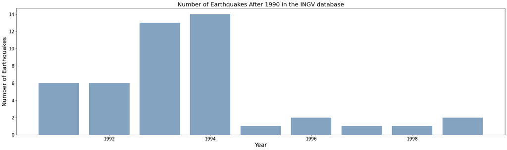

```python
plt.figure(figsize = (30, 8))
qyr4 = qkAfter1990_df.groupby( ["Year"] ).size().reset_index(name='count')
xy = qyr4['Year'] # what goes on the x-axis
yy = qyr4['count']   # what goes on the y-axis
plt.bar(xy,yy, color=(0.2, 0.4, 0.6, 0.6))
# plt.plot(avocados_boston.date, avocados_boston.average_price, color = 'green', linestyle = '--', marker = 'o')
plt.xlabel("Year",fontsize=20)
plt.ylabel("Number of Earthquakes",fontsize=20)
plt.title("Number of Earthquakes After 1990 in the INGV database",fontsize=20)
plt.xticks(fontsize=15)
plt.yticks(fontsize=15)
plt.show()
```

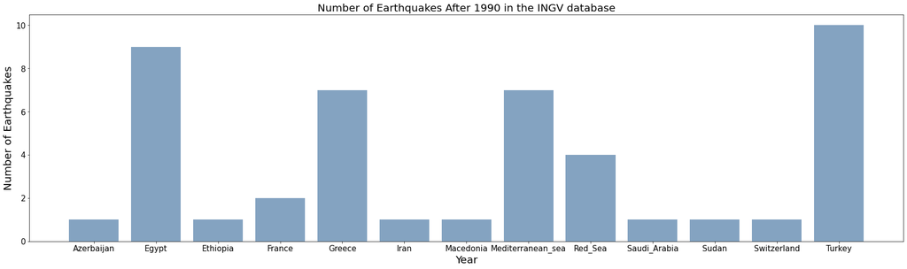

```python
plt.figure(figsize = (30, 8))
qyr4 = qkAfter1990_df.groupby( ["Country"] ).size().reset_index(name='count')
xy = qyr4['Country'] # what goes on the x-axis
yy = qyr4['count']   # what goes on the y-axis
plt.bar(xy,yy, color=(0.2, 0.4, 0.6, 0.6))
# plt.plot(avocados_boston.date, avocados_boston.average_price, color = 'green', linestyle = '--', marker = 'o')
plt.xlabel("Year",fontsize=20)
plt.ylabel("Number of Earthquakes",fontsize=20)
plt.title("Number of Earthquakes After 1990 in the INGV database",fontsize=20)
plt.xticks(fontsize=15)
plt.yticks(fontsize=15)
plt.show()
```